# Face Generation

In this project, you'll use generative adversarial networks to generate new images of faces.

### Get the Data

You'll be using two datasets in this project:

- MNIST
- CelebA

Since the celebA dataset is complex and you're doing GANs in a project for the first time, we want you to test your neural network on MNIST before CelebA. Running the GANs on MNIST will allow you to see how well your model trains sooner.

If you're using [FloydHub](https://www.floydhub.com/), set `data_dir` to "/input" and use the [FloydHub data ID](http://docs.floydhub.com/home/using_datasets/) "R5KrjnANiKVhLWAkpXhNBe".

```python
data_dir = './data'

# FloydHub - Use with data ID "R5KrjnANiKVhLWAkpXhNBe"
#data_dir = '/input'


"""
DON'T MODIFY ANYTHING IN THIS CELL
"""
import helper

helper.download_extract('mnist', data_dir)
helper.download_extract('celeba', data_dir)
```

```
Found mnist Data
Found celeba Data
```

## Explore the Data

### MNIST

As you're aware, the [MNIST](http://yann.lecun.com/exdb/mnist/) dataset contains images of handwritten digits. You can view the first number of examples by changing `show_n_images`.

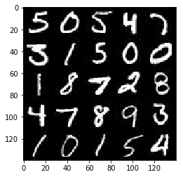

```python
show_n_images = 25

"""
DON'T MODIFY ANYTHING IN THIS CELL
"""
%matplotlib inline
import os
from glob import glob
from matplotlib import pyplot

mnist_images = helper.get_batch(glob(os.path.join(data_dir, 'mnist/*.jpg'))[:show_n_images], 28, 28, 'L')
pyplot.imshow(helper.images_square_grid(mnist_images, 'L'), cmap='gray')
```

### CelebA

The [CelebFaces Attributes Dataset (CelebA)](http://mmlab.ie.cuhk.edu.hk/projects/CelebA.html) dataset contains over 200,000 celebrity images with annotations. Since you're going to be generating faces, you won't need the annotations. You can view the first number of examples by changing `show_n_images`.

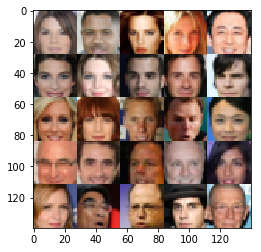

```python
show_n_images = 25

"""
DON'T MODIFY ANYTHING IN THIS CELL
"""
mnist_images = helper.get_batch(glob(os.path.join(data_dir, 'img_align_celeba/*.jpg'))[:show_n_images], 28, 28, 'RGB')
pyplot.imshow(helper.images_square_grid(mnist_images, 'RGB'))
```

## Preprocess the Data

Since the project's main focus is on building the GANs, we'll preprocess the data for you. The values of the MNIST and CelebA dataset will be in the range of -0.5 to 0.5 of 28x28 dimensional images. The CelebA images will be cropped to remove parts of the image that don't include a face, then resized down to 28x28.

The MNIST images are black and white images with a single color channel while the CelebA images have 3 color channels (RGB color channel).

## Build the Neural Network

You'll build the components necessary to build a GANs by implementing the following functions below:

- `model_inputs`
- `discriminator`
- `generator`
- `model_loss`
- `model_opt`
- `train`

### Check the Version of TensorFlow and Access to GPU

This will check to make sure you have the correct version of TensorFlow and access to a GPU

```python
"""
DON'T MODIFY ANYTHING IN THIS CELL
"""
from distutils.version import LooseVersion
import warnings
import tensorflow as tf

# Check TensorFlow Version
assert LooseVersion(tf.__version__) >= LooseVersion('1.0'), 'Please use TensorFlow version 1.0 or newer.  You are using {}'.format(tf.__version__)
print('TensorFlow Version: {}'.format(tf.__version__))

# Check for a GPU
if not tf.test.gpu_device_name():
    warnings.warn('No GPU found. Please use a GPU to train your neural network.')
else:
    print('Default GPU Device: {}'.format(tf.test.gpu_device_name()))
```

```
TensorFlow Version: 1.0.0
Default GPU Device: /gpu:0
```

### Input

Implement the `model_inputs` function to create TF Placeholders for the Neural Network. It should create the following placeholders:

- Real input images placeholder with rank 4 using `image_width`, `image_height`, and `image_channels`.
- Z input placeholder with rank 2 using `z_dim`.
- Learning rate placeholder with rank 0.

Return the placeholders in the following the tuple (tensor of real input images, tensor of z data)

```python
import problem_unittests as tests

def model_inputs(image_width, image_height, image_channels, z_dim):
    """
    Create the model inputs
    :param image_width: The input image width
    :param image_height: The input image height
    :param image_channels: The number of image channels
    :param z_dim: The dimension of Z
    :return: Tuple of (tensor of real input images, tensor of z data, learning rate)
    """
    # TODO: Implement Function
    input_real = tf.placeholder(dtype=tf.float32, \
                                shape=[None, image_width, image_height, image_channels], \
                                name="input_real")

    input_z = tf.placeholder(dtype=tf.float32, \
                             shape=[None, z_dim], \
                             name='input_z')

    learning_rate = tf.placeholder(dtype=tf.float32, name='learning_rate')
    return input_real, input_z, learning_rate


"""
DON'T MODIFY ANYTHING IN THIS CELL THAT IS BELOW THIS LINE
"""
tests.test_model_inputs(model_inputs)
```

```
Tests Passed
```

### Discriminator

Implement `discriminator` to create a discriminator neural network that discriminates on `images`. This function should be able to reuse the variables in the neural network. Use [`tf.variable_scope`](https://www.tensorflow.org/api_docs/python/tf/variable_scope) with a scope name of "discriminator" to allow the variables to be reused. The function should return a tuple of (tensor output of the discriminator, tensor logits of the discriminator).

```python
def discriminator(images, reuse=False):
    """
    Create the discriminator network
    :param images: Tensor of input image(s)
    :param reuse: Boolean if the weights should be reused
    :return: Tuple of (tensor output of the discriminator, tensor logits of the discriminator)
    """
    # TODO: Implement Function
    with tf.variable_scope('discriminator', reuse=reuse):
        alpha = 0.2
        z1 = tf.layers.conv2d(images, filters=32, kernel_size=4, strides=2, padding='same', \
                              activation=None, use_bias=False)
        z1 = tf.layers.batch_normalization(z1, training=True)
        z1 = tf.maximum(alpha*z1, z1)

        z2 = tf.layers.conv2d(z1, filters=64, kernel_size=4, strides=2, padding='same', \
                              activation=None, use_bias=False)
        z2 = tf.layers.batch_normalization(z2, training=True)
        z2 = tf.maximum(alpha*z2, z2)
        z2_shape = z2.get_shape().as_list()

        z3 = tf.reshape(z2, shape=[-1, z2_shape[1]*z2_shape[2]*z2_shape[3]]) # from tensor z2.get_shape()
        logits = tf.layers.dense(z3, 1, activation=None, use_bias=True) # final layer use bias for no batch normalization implemented
        output = tf.sigmoid(logits)
    return output, logits


"""
DON'T MODIFY ANYTHING IN THIS CELL THAT IS BELOW THIS LINE
"""
tests.test_discriminator(discriminator, tf)
```

```
Tests Passed
```

### Generator

Implement `generator` to generate an image using `z`. This function should be able to reuse the variables in the neural network. Use [`tf.variable_scope`](https://www.tensorflow.org/api_docs/python/tf/variable_scope) with a scope name of "generator" to allow the variables to be reused. The function should return the generated 28 x 28 x `out_channel_dim` images.

```python
def generator(z, out_channel_dim, is_train=True):
    """
    Create the generator network
    :param z: Input z
    :param out_channel_dim: The number of channels in the output image
    :param is_train: Boolean if generator is being used for training
    :return: The tensor output of the generator
    """
    # TODO: Implement Function
    with tf.variable_scope('generator', reuse=not is_train):
        alpha = 0.2
        x1 = tf.layers.dense(z, units=7*7*512, activation=None)
        x1 = tf.reshape(x1, shape=[-1, 7, 7, 512])
        x1 = tf.layers.batch_normalization(x1, training=is_train)
        x1 = tf.maximum(alpha*x1, x1)
        # Output shape 7x7x512

        x2 = tf.layers.conv2d_transpose(x1, filters=256, kernel_size=4, strides=2, padding='same', \
                                        activation=None, use_bias=False)
        x2 = tf.layers.batch_normalization(x2, training=is_train)
        x2 = tf.maximum(alpha*x2, x2)
        # Output shape 14x14x256

        x3 = tf.layers.conv2d_transpose(x2, filters=128, kernel_size=4, strides=2, padding='same', \
                                            activation=None, use_bias=False)
        x3 = tf.layers.batch_normalization(x3, training=is_train)
        x3 = tf.maximum(alpha*x3, x3)
        # Output shape 28x28x128

        logits = tf.layers.conv2d_transpose(x3, filters=out_channel_dim, kernel_size=4, strides=1, padding='same', \
                                            activation=None, use_bias=True) # for fitting to out_channel_dim
        # Output shape 28x28xout_channel_dim

        output = tf.tanh(logits)

    return output


"""
DON'T MODIFY ANYTHING IN THIS CELL THAT IS BELOW THIS LINE
"""
tests.test_generator(generator, tf)
```

```
Tests Passed
```

### Loss

Implement `model_loss` to build the GANs for training and calculate the loss. The function should return a tuple of (discriminator loss, generator loss). Use the following functions you implemented:

- `discriminator(images, reuse=False)`
- `generator(z, out_channel_dim, is_train=True)`

```python
def model_loss(input_real, input_z, out_channel_dim):
    """
    Get the loss for the discriminator and generator
    :param input_real: Images from the real dataset
    :param input_z: Z input
    :param out_channel_dim: The number of channels in the output image
    :return: A tuple of (discriminator loss, generator loss)
    """
    # TODO: Implement Function
    g_images = generator(input_z, out_channel_dim)

    output_real , logits_real = discriminator(input_real)
    output_fake, logits_fake = discriminator(g_images, reuse=True)
    d_real_loss = tf.reduce_mean(tf.nn.sigmoid_cross_entropy_with_logits(labels=tf.ones_like(logits_real), \
                                                                         logits=logits_real))
    d_fake_loss = tf.reduce_mean(tf.nn.sigmoid_cross_entropy_with_logits(labels=tf.zeros_like(logits_fake), \
                                                                         logits=logits_fake))
    d_loss = d_real_loss + d_fake_loss

    g_loss = tf.reduce_mean(tf.nn.sigmoid_cross_entropy_with_logits(labels=tf.ones_like(logits_fake), \
                                                                    logits=logits_fake))

    return d_loss, g_loss


"""
DON'T MODIFY ANYTHING IN THIS CELL THAT IS BELOW THIS LINE
"""
tests.test_model_loss(model_loss)
```

```
Tests Passed
```

### Optimization

Implement `model_opt` to create the optimization operations for the GANs. Use [`tf.trainable_variables`](https://www.tensorflow.org/api_docs/python/tf/trainable_variables) to get all the trainable variables. Filter the variables with names that are in the discriminator and generator scope names. The function should return a tuple of (discriminator training operation, generator training operation).

```python
def model_opt(d_loss, g_loss, learning_rate, beta1):
    """
    Get optimization operations
    :param d_loss: Discriminator loss Tensor
    :param g_loss: Generator loss Tensor
    :param learning_rate: Learning Rate Placeholder
    :param beta1: The exponential decay rate for the 1st moment in the optimizer
    :return: A tuple of (discriminator training operation, generator training operation)
    """
    # TODO: Implement Function
    t_vars = tf.trainable_variables()
    d_vars = [var for var in t_vars if var.name.startswith('discriminator')]
    g_vars = [var for var in t_vars if var.name.startswith('generator')]

    with tf.control_dependencies(tf.get_collection(tf.GraphKeys.UPDATE_OPS)):
        d_train_opt = tf.train.AdamOptimizer(learning_rate=learning_rate, beta1=beta1).minimize(d_loss, \
                                                                                                var_list=d_vars)
        g_train_opt = tf.train.AdamOptimizer(learning_rate=learning_rate, beta1=beta1).minimize(g_loss, \
                                                                                                var_list=g_vars)


    return d_train_opt, g_train_opt


"""
DON'T MODIFY ANYTHING IN THIS CELL THAT IS BELOW THIS LINE
"""
tests.test_model_opt(model_opt, tf)
```

```
Tests Passed
```

## Neural Network Training

### Show Output

Use this function to show the current output of the generator during training. It will help you determine how well the GANs is training.

```python
"""
DON'T MODIFY ANYTHING IN THIS CELL
"""
import numpy as np

def show_generator_output(sess, n_images, input_z, out_channel_dim, image_mode):
    """
    Show example output for the generator
    :param sess: TensorFlow session
    :param n_images: Number of Images to display
    :param input_z: Input Z Tensor
    :param out_channel_dim: The number of channels in the output image
    :param image_mode: The mode to use for images ("RGB" or "L")
    """
    cmap = None if image_mode == 'RGB' else 'gray'
    z_dim = input_z.get_shape().as_list()[-1]
    example_z = np.random.uniform(-1, 1, size=[n_images, z_dim])

    samples = sess.run(
        generator(input_z, out_channel_dim, False),
        feed_dict={input_z: example_z})

    images_grid = helper.images_square_grid(samples, image_mode)
    pyplot.imshow(images_grid, cmap=cmap)
    pyplot.show()
```

### Train

Implement `train` to build and train the GANs. Use the following functions you implemented:

- `model_inputs(image_width, image_height, image_channels, z_dim)`
- `model_loss(input_real, input_z, out_channel_dim)`
- `model_opt(d_loss, g_loss, learning_rate, beta1)`

Use the `show_generator_output` to show `generator` output while you train. Running `show_generator_output` for every batch will drastically increase training time and increase the size of the notebook. It's recommended to print the `generator` output every 100 batches.

```python
def train(epoch_count, batch_size, z_dim, learning_rate, beta1, get_batches, data_shape, data_image_mode):
    """
    Train the GAN
    :param epoch_count: Number of epochs
    :param batch_size: Batch Size
    :param z_dim: Z dimension
    :param learning_rate: Learning Rate
    :param beta1: The exponential decay rate for the 1st moment in the optimizer
    :param get_batches: Function to get batches
    :param data_shape: Shape of the data
    :param data_image_mode: The image mode to use for images ("RGB" or "L")
    """
    # TODO: Build Model
    input_real_holder, input_z_holder, learning_rate_holder = model_inputs(data_shape[1], data_shape[2], \
                                                                           data_shape[3], z_dim)
    d_loss, g_loss = model_loss(input_real_holder, input_z_holder, data_shape[3])
    d_train_opt, g_train_opt = model_opt(d_loss, g_loss, learning_rate_holder, beta1)

    saver = tf.train.Saver() # for saving all the variables above
    step = 0

    with tf.Session() as sess:
        sess.run(tf.global_variables_initializer())

        for epoch_i in range(epoch_count):
            for batch_images in get_batches(batch_size):
                step += 1

                # get batches for fake images
                batch_z = np.random.uniform(-1,1, size=(batch_size, z_dim))

                # TODO: Train Model
                _ =sess.run(d_train_opt, feed_dict={input_real_holder: batch_images, \
                                                    input_z_holder: batch_z, \
                                                    learning_rate_holder: learning_rate})
                _ = sess.run(g_train_opt, feed_dict={input_z_holder: batch_z, \
                                                     input_real_holder: batch_images, \
                                                     learning_rate_holder: learning_rate})

                if step % 10 == 0:
                    train_d_loss = d_loss.eval({input_real_holder: batch_images, input_z_holder: batch_z})
                    train_g_loss = g_loss.eval({input_z_holder: batch_z})

                    print('Epoch: {}/{}...'.format(epoch_i+1, epoch_count),
                          'Discriminator Training Loss: {:.4f}'.format(train_d_loss),
                          'Generator Training Loss: {:.4f}'.format(train_g_loss))

                if step % 100 == 0:
                    _ = show_generator_output(sess, n_images=16, input_z=input_z_holder, \
                                              out_channel_dim=data_shape[3], image_mode=data_image_mode)

        # print out the generated sample from final model
        _ = show_generator_output(sess, n_images=16, input_z=input_z_holder, \
                                  out_channel_dim=data_shape[3], image_mode=data_image_mode)

        saver.save(sess, './generator.ckpt')
```

### MNIST

Test your GANs architecture on MNIST. After 2 epochs, the GANs should be able to generate images that look like handwritten digits. Make sure the loss of the generator is lower than the loss of the discriminator or close to 0.

```
Epoch: 1/2... Discriminator Training Loss: 4.5040 Generator Training Loss: 0.0186
Epoch: 1/2... Discriminator Training Loss: 4.7400 Generator Training Loss: 0.0146
Epoch: 1/2... Discriminator Training Loss: 4.6469 Generator Training Loss: 0.0221
Epoch: 1/2... Discriminator Training Loss: 4.2771 Generator Training Loss: 0.0372
Epoch: 1/2... Discriminator Training Loss: 2.9891 Generator Training Loss: 0.1400
Epoch: 1/2... Discriminator Training Loss: 2.1750 Generator Training Loss: 0.3744
Epoch: 1/2... Discriminator Training Loss: 1.9758 Generator Training Loss: 0.9074
Epoch: 1/2... Discriminator Training Loss: 2.8260 Generator Training Loss: 0.2648
Epoch: 1/2... Discriminator Training Loss: 2.4303 Generator Training Loss: 0.3938
Epoch: 1/2... Discriminator Training Loss: 2.6408 Generator Training Loss: 0.3116
```

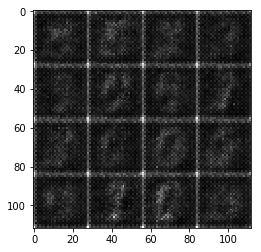

```
Epoch: 1/2... Discriminator Training Loss: 2.5846 Generator Training Loss: 0.2962
Epoch: 1/2... Discriminator Training Loss: 2.5569 Generator Training Loss: 0.3312
Epoch: 1/2... Discriminator Training Loss: 2.3781 Generator Training Loss: 0.3270
Epoch: 1/2... Discriminator Training Loss: 2.3415 Generator Training Loss: 0.3529
Epoch: 1/2... Discriminator Training Loss: 2.1697 Generator Training Loss: 0.3782
Epoch: 1/2... Discriminator Training Loss: 2.2607 Generator Training Loss: 0.3466
Epoch: 1/2... Discriminator Training Loss: 1.7329 Generator Training Loss: 0.5210
Epoch: 1/2... Discriminator Training Loss: 2.0504 Generator Training Loss: 0.4201
Epoch: 1/2... Discriminator Training Loss: 1.9894 Generator Training Loss: 0.4283
Epoch: 1/2... Discriminator Training Loss: 2.0319 Generator Training Loss: 0.4300
```

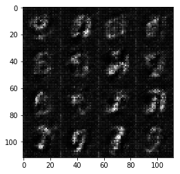

```
Epoch: 1/2... Discriminator Training Loss: 1.9170 Generator Training Loss: 0.4509
Epoch: 1/2... Discriminator Training Loss: 1.7776 Generator Training Loss: 0.5158
Epoch: 1/2... Discriminator Training Loss: 1.7571 Generator Training Loss: 0.4967
Epoch: 1/2... Discriminator Training Loss: 1.4896 Generator Training Loss: 0.6735
Epoch: 1/2... Discriminator Training Loss: 1.8396 Generator Training Loss: 0.5002
Epoch: 1/2... Discriminator Training Loss: 1.7151 Generator Training Loss: 0.5757
Epoch: 1/2... Discriminator Training Loss: 1.7269 Generator Training Loss: 0.5343
Epoch: 1/2... Discriminator Training Loss: 1.6609 Generator Training Loss: 0.5577
Epoch: 1/2... Discriminator Training Loss: 1.6470 Generator Training Loss: 0.5700
Epoch: 1/2... Discriminator Training Loss: 1.6130 Generator Training Loss: 0.5735
```

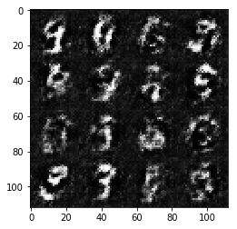

```
Epoch: 1/2... Discriminator Training Loss: 1.5215 Generator Training Loss: 0.6111
Epoch: 1/2... Discriminator Training Loss: 1.6063 Generator Training Loss: 0.5739
Epoch: 1/2... Discriminator Training Loss: 1.5137 Generator Training Loss: 0.6065
Epoch: 1/2... Discriminator Training Loss: 1.4896 Generator Training Loss: 0.6293
Epoch: 1/2... Discriminator Training Loss: 1.4377 Generator Training Loss: 0.6596
Epoch: 1/2... Discriminator Training Loss: 1.4313 Generator Training Loss: 0.6581
Epoch: 1/2... Discriminator Training Loss: 1.4507 Generator Training Loss: 0.6335
Epoch: 1/2... Discriminator Training Loss: 1.4469 Generator Training Loss: 0.6338
Epoch: 1/2... Discriminator Training Loss: 1.4171 Generator Training Loss: 0.6464
Epoch: 1/2... Discriminator Training Loss: 1.4149 Generator Training Loss: 0.6533
```

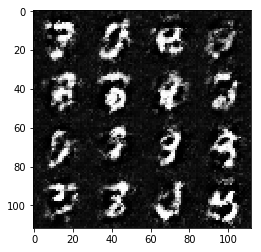

```
Epoch: 1/2... Discriminator Training Loss: 1.3543 Generator Training Loss: 0.6721
Epoch: 1/2... Discriminator Training Loss: 1.3672 Generator Training Loss: 0.6840
Epoch: 1/2... Discriminator Training Loss: 1.2910 Generator Training Loss: 0.6945
Epoch: 1/2... Discriminator Training Loss: 1.2969 Generator Training Loss: 0.7067
Epoch: 1/2... Discriminator Training Loss: 1.2706 Generator Training Loss: 0.7294
Epoch: 1/2... Discriminator Training Loss: 1.2468 Generator Training Loss: 0.7510
Epoch: 1/2... Discriminator Training Loss: 1.2331 Generator Training Loss: 0.7571
Epoch: 1/2... Discriminator Training Loss: 1.2193 Generator Training Loss: 0.7314
Epoch: 1/2... Discriminator Training Loss: 1.2004 Generator Training Loss: 0.7751
Epoch: 1/2... Discriminator Training Loss: 1.2006 Generator Training Loss: 0.7694
```

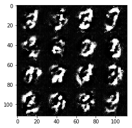

```
Epoch: 1/2... Discriminator Training Loss: 1.1221 Generator Training Loss: 0.8049
Epoch: 1/2... Discriminator Training Loss: 1.1619 Generator Training Loss: 0.7679
Epoch: 1/2... Discriminator Training Loss: 1.0293 Generator Training Loss: 0.8594
Epoch: 1/2... Discriminator Training Loss: 1.0400 Generator Training Loss: 0.8503
Epoch: 1/2... Discriminator Training Loss: 0.9821 Generator Training Loss: 0.8882
Epoch: 1/2... Discriminator Training Loss: 0.9064 Generator Training Loss: 0.9232
Epoch: 1/2... Discriminator Training Loss: 0.8631 Generator Training Loss: 1.0297
Epoch: 1/2... Discriminator Training Loss: 0.7918 Generator Training Loss: 1.1149
Epoch: 1/2... Discriminator Training Loss: 0.8855 Generator Training Loss: 0.9438
Epoch: 1/2... Discriminator Training Loss: 0.5985 Generator Training Loss: 1.2845
```

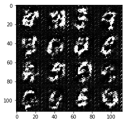

```
Epoch: 1/2... Discriminator Training Loss: 0.4983 Generator Training Loss: 1.6328
Epoch: 1/2... Discriminator Training Loss: 0.6628 Generator Training Loss: 1.2759
Epoch: 1/2... Discriminator Training Loss: 0.5743 Generator Training Loss: 1.3023
Epoch: 1/2... Discriminator Training Loss: 0.5596 Generator Training Loss: 1.4367
Epoch: 1/2... Discriminator Training Loss: 0.3225 Generator Training Loss: 1.8316
Epoch: 1/2... Discriminator Training Loss: 0.2549 Generator Training Loss: 2.0378
Epoch: 1/2... Discriminator Training Loss: 0.6024 Generator Training Loss: 1.0869
Epoch: 1/2... Discriminator Training Loss: 0.4994 Generator Training Loss: 1.4558
Epoch: 1/2... Discriminator Training Loss: 0.3911 Generator Training Loss: 1.6325
Epoch: 1/2... Discriminator Training Loss: 0.2650 Generator Training Loss: 1.9481
```

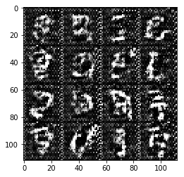

```
Epoch: 1/2... Discriminator Training Loss: 0.3377 Generator Training Loss: 1.5743
Epoch: 1/2... Discriminator Training Loss: 0.2170 Generator Training Loss: 1.9485
Epoch: 1/2... Discriminator Training Loss: 0.1946 Generator Training Loss: 2.0201
Epoch: 1/2... Discriminator Training Loss: 0.1140 Generator Training Loss: 2.7258
Epoch: 1/2... Discriminator Training Loss: 0.3620 Generator Training Loss: 3.0504
Epoch: 1/2... Discriminator Training Loss: 0.3691 Generator Training Loss: 1.7290
Epoch: 1/2... Discriminator Training Loss: 0.3096 Generator Training Loss: 1.7564
Epoch: 1/2... Discriminator Training Loss: 0.2996 Generator Training Loss: 2.0302
Epoch: 1/2... Discriminator Training Loss: 0.3065 Generator Training Loss: 1.5937
Epoch: 1/2... Discriminator Training Loss: 0.2164 Generator Training Loss: 2.1093
```

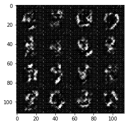

```
Epoch: 1/2... Discriminator Training Loss: 0.2122 Generator Training Loss: 1.8721
Epoch: 1/2... Discriminator Training Loss: 0.1272 Generator Training Loss: 2.6466
Epoch: 1/2... Discriminator Training Loss: 0.2937 Generator Training Loss: 1.8960
Epoch: 1/2... Discriminator Training Loss: 0.2545 Generator Training Loss: 3.0043
Epoch: 1/2... Discriminator Training Loss: 0.1836 Generator Training Loss: 2.5352
Epoch: 1/2... Discriminator Training Loss: 0.1709 Generator Training Loss: 3.9522
Epoch: 1/2... Discriminator Training Loss: 0.2350 Generator Training Loss: 2.5758
Epoch: 1/2... Discriminator Training Loss: 0.9586 Generator Training Loss: 0.5564
Epoch: 1/2... Discriminator Training Loss: 1.1827 Generator Training Loss: 0.3961
Epoch: 1/2... Discriminator Training Loss: 0.7663 Generator Training Loss: 0.6938
```

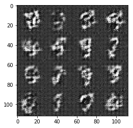

```
Epoch: 1/2... Discriminator Training Loss: 0.7629 Generator Training Loss: 0.7850
Epoch: 1/2... Discriminator Training Loss: 0.5294 Generator Training Loss: 1.0657
Epoch: 1/2... Discriminator Training Loss: 0.8969 Generator Training Loss: 0.6122
Epoch: 2/2... Discriminator Training Loss: 0.2601 Generator Training Loss: 2.5769
Epoch: 2/2... Discriminator Training Loss: 0.3473 Generator Training Loss: 1.8512
Epoch: 2/2... Discriminator Training Loss: 0.5468 Generator Training Loss: 1.0530
Epoch: 2/2... Discriminator Training Loss: 0.6033 Generator Training Loss: 4.5114
Epoch: 2/2... Discriminator Training Loss: 0.2810 Generator Training Loss: 2.9903
Epoch: 2/2... Discriminator Training Loss: 0.3438 Generator Training Loss: 3.2882
Epoch: 2/2... Discriminator Training Loss: 0.5098 Generator Training Loss: 3.2169
```

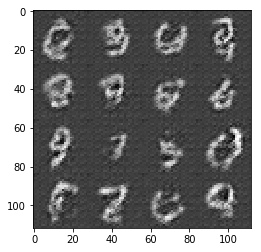

```
Epoch: 2/2... Discriminator Training Loss: 0.5216 Generator Training Loss: 2.9899
Epoch: 2/2... Discriminator Training Loss: 0.5928 Generator Training Loss: 1.9059
Epoch: 2/2... Discriminator Training Loss: 1.7051 Generator Training Loss: 0.2330
Epoch: 2/2... Discriminator Training Loss: 1.5185 Generator Training Loss: 0.4102
Epoch: 2/2... Discriminator Training Loss: 0.5354 Generator Training Loss: 4.6791
Epoch: 2/2... Discriminator Training Loss: 1.2054 Generator Training Loss: 0.7512
Epoch: 2/2... Discriminator Training Loss: 1.4963 Generator Training Loss: 1.1083
Epoch: 2/2... Discriminator Training Loss: 1.8461 Generator Training Loss: 0.2165
Epoch: 2/2... Discriminator Training Loss: 1.4694 Generator Training Loss: 0.3805
Epoch: 2/2... Discriminator Training Loss: 0.8622 Generator Training Loss: 1.5860
```

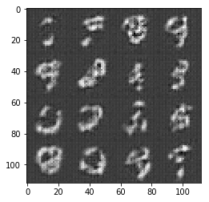

```
Epoch: 2/2... Discriminator Training Loss: 0.9559 Generator Training Loss: 0.8576
Epoch: 2/2... Discriminator Training Loss: 1.6161 Generator Training Loss: 0.2968
Epoch: 2/2... Discriminator Training Loss: 1.3458 Generator Training Loss: 0.4489
Epoch: 2/2... Discriminator Training Loss: 0.9828 Generator Training Loss: 1.4941
Epoch: 2/2... Discriminator Training Loss: 0.7601 Generator Training Loss: 2.9742
Epoch: 2/2... Discriminator Training Loss: 1.4342 Generator Training Loss: 0.3465
Epoch: 2/2... Discriminator Training Loss: 1.0446 Generator Training Loss: 1.0359
Epoch: 2/2... Discriminator Training Loss: 0.9343 Generator Training Loss: 1.5422
Epoch: 2/2... Discriminator Training Loss: 1.3246 Generator Training Loss: 0.4401
Epoch: 2/2... Discriminator Training Loss: 1.2326 Generator Training Loss: 0.5443
```

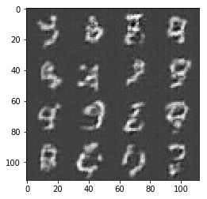

```
Epoch: 2/2... Discriminator Training Loss: 1.0513 Generator Training Loss: 0.7505
Epoch: 2/2... Discriminator Training Loss: 1.0137 Generator Training Loss: 1.0721
Epoch: 2/2... Discriminator Training Loss: 1.2345 Generator Training Loss: 0.5146
Epoch: 2/2... Discriminator Training Loss: 0.8429 Generator Training Loss: 1.1309
Epoch: 2/2... Discriminator Training Loss: 0.6763 Generator Training Loss: 1.4155
Epoch: 2/2... Discriminator Training Loss: 0.9135 Generator Training Loss: 1.0558
Epoch: 2/2... Discriminator Training Loss: 1.0264 Generator Training Loss: 0.6560
Epoch: 2/2... Discriminator Training Loss: 1.0234 Generator Training Loss: 0.8965
Epoch: 2/2... Discriminator Training Loss: 0.7902 Generator Training Loss: 1.1348
Epoch: 2/2... Discriminator Training Loss: 0.9598 Generator Training Loss: 0.8168
```

[7 more figures not shown]

```python
batch_size = 64
z_dim = 100
learning_rate = 0.0002
beta1 = 0.6


"""
DON'T MODIFY ANYTHING IN THIS CELL THAT IS BELOW THIS LINE
"""
epochs = 2

mnist_dataset = helper.Dataset('mnist', glob(os.path.join(data_dir, 'mnist/*.jpg')))
with tf.Graph().as_default():
    train(epochs, batch_size, z_dim, learning_rate, beta1, mnist_dataset.get_batches,
          mnist_dataset.shape, mnist_dataset.image_mode)
```

### CelebA

Run your GANs on CelebA. It will take around 20 minutes on the average GPU to run one epoch. You can run the whole epoch or stop when it starts to generate realistic faces.

```
Epoch: 1/1... Discriminator Training Loss: 4.9242 Generator Training Loss: 0.0130
Epoch: 1/1... Discriminator Training Loss: 5.1124 Generator Training Loss: 0.0124
Epoch: 1/1... Discriminator Training Loss: 5.3649 Generator Training Loss: 0.0124
Epoch: 1/1... Discriminator Training Loss: 5.1198 Generator Training Loss: 0.0138
Epoch: 1/1... Discriminator Training Loss: 5.2552 Generator Training Loss: 0.0149
Epoch: 1/1... Discriminator Training Loss: 5.4159 Generator Training Loss: 0.0204
Epoch: 1/1... Discriminator Training Loss: 2.7119 Generator Training Loss: 0.3687
Epoch: 1/1... Discriminator Training Loss: 4.4070 Generator Training Loss: 0.0706
Epoch: 1/1... Discriminator Training Loss: 4.8206 Generator Training Loss: 0.0957
Epoch: 1/1... Discriminator Training Loss: 4.0064 Generator Training Loss: 0.1651
```

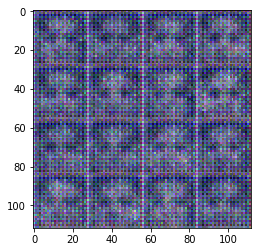

```
Epoch: 1/1... Discriminator Training Loss: 3.4331 Generator Training Loss: 0.2149
Epoch: 1/1... Discriminator Training Loss: 2.6523 Generator Training Loss: 0.2514
Epoch: 1/1... Discriminator Training Loss: 3.0934 Generator Training Loss: 0.1856
Epoch: 1/1... Discriminator Training Loss: 2.0466 Generator Training Loss: 0.6763
Epoch: 1/1... Discriminator Training Loss: 1.9145 Generator Training Loss: 0.8520
Epoch: 1/1... Discriminator Training Loss: 2.4016 Generator Training Loss: 0.3350
Epoch: 1/1... Discriminator Training Loss: 2.0795 Generator Training Loss: 0.3486
Epoch: 1/1... Discriminator Training Loss: 2.5168 Generator Training Loss: 0.3041
Epoch: 1/1... Discriminator Training Loss: 2.0324 Generator Training Loss: 0.3747
Epoch: 1/1... Discriminator Training Loss: 2.8530 Generator Training Loss: 0.2793
```

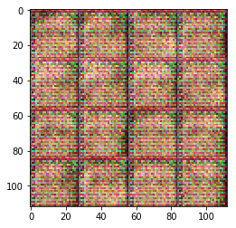

```
Epoch: 1/1... Discriminator Training Loss: 2.1951 Generator Training Loss: 0.4886
Epoch: 1/1... Discriminator Training Loss: 2.8634 Generator Training Loss: 0.3302
Epoch: 1/1... Discriminator Training Loss: 3.0800 Generator Training Loss: 0.3664
Epoch: 1/1... Discriminator Training Loss: 2.3215 Generator Training Loss: 1.0043
Epoch: 1/1... Discriminator Training Loss: 2.3264 Generator Training Loss: 0.5100
Epoch: 1/1... Discriminator Training Loss: 2.6241 Generator Training Loss: 0.2834
Epoch: 1/1... Discriminator Training Loss: 2.4302 Generator Training Loss: 0.4083
Epoch: 1/1... Discriminator Training Loss: 2.2778 Generator Training Loss: 0.4037
Epoch: 1/1... Discriminator Training Loss: 2.5320 Generator Training Loss: 0.3679
Epoch: 1/1... Discriminator Training Loss: 2.2118 Generator Training Loss: 0.4329
```

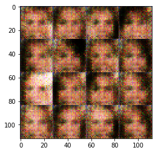

```
Epoch: 1/1... Discriminator Training Loss: 1.8117 Generator Training Loss: 0.6803
Epoch: 1/1... Discriminator Training Loss: 2.1446 Generator Training Loss: 0.4733
Epoch: 1/1... Discriminator Training Loss: 2.3797 Generator Training Loss: 0.3920
Epoch: 1/1... Discriminator Training Loss: 2.3060 Generator Training Loss: 0.3865
Epoch: 1/1... Discriminator Training Loss: 2.4363 Generator Training Loss: 0.3699
Epoch: 1/1... Discriminator Training Loss: 2.3463 Generator Training Loss: 0.4138
Epoch: 1/1... Discriminator Training Loss: 2.1870 Generator Training Loss: 0.3908
Epoch: 1/1... Discriminator Training Loss: 2.0177 Generator Training Loss: 0.4833
Epoch: 1/1... Discriminator Training Loss: 2.0754 Generator Training Loss: 0.4591
Epoch: 1/1... Discriminator Training Loss: 2.0741 Generator Training Loss: 0.4524
```

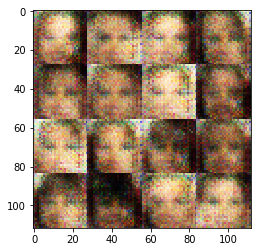

```
Epoch: 1/1... Discriminator Training Loss: 1.9675 Generator Training Loss: 0.5043
Epoch: 1/1... Discriminator Training Loss: 2.0364 Generator Training Loss: 0.4576
Epoch: 1/1... Discriminator Training Loss: 2.1480 Generator Training Loss: 0.4157
Epoch: 1/1... Discriminator Training Loss: 1.9143 Generator Training Loss: 0.5268
Epoch: 1/1... Discriminator Training Loss: 2.0047 Generator Training Loss: 0.4997
Epoch: 1/1... Discriminator Training Loss: 1.9214 Generator Training Loss: 0.4590
Epoch: 1/1... Discriminator Training Loss: 1.9385 Generator Training Loss: 0.4533
Epoch: 1/1... Discriminator Training Loss: 1.9653 Generator Training Loss: 0.4341
Epoch: 1/1... Discriminator Training Loss: 1.8941 Generator Training Loss: 0.4775
Epoch: 1/1... Discriminator Training Loss: 1.9475 Generator Training Loss: 0.4573
```

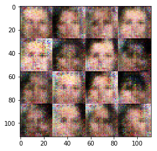

```
Epoch: 1/1... Discriminator Training Loss: 1.7615 Generator Training Loss: 0.5405
Epoch: 1/1... Discriminator Training Loss: 1.8023 Generator Training Loss: 0.5668
Epoch: 1/1... Discriminator Training Loss: 1.7576 Generator Training Loss: 0.5564
Epoch: 1/1... Discriminator Training Loss: 1.8236 Generator Training Loss: 0.5102
Epoch: 1/1... Discriminator Training Loss: 1.7636 Generator Training Loss: 0.5361
Epoch: 1/1... Discriminator Training Loss: 1.7449 Generator Training Loss: 0.5467
Epoch: 1/1... Discriminator Training Loss: 1.6312 Generator Training Loss: 0.5644
Epoch: 1/1... Discriminator Training Loss: 1.7303 Generator Training Loss: 0.5229
Epoch: 1/1... Discriminator Training Loss: 1.6708 Generator Training Loss: 0.5468
Epoch: 1/1... Discriminator Training Loss: 1.7732 Generator Training Loss: 0.5302
```

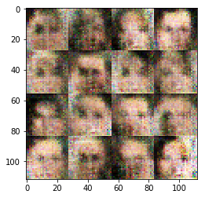

```
Epoch: 1/1... Discriminator Training Loss: 1.7486 Generator Training Loss: 0.5130
Epoch: 1/1... Discriminator Training Loss: 1.6135 Generator Training Loss: 0.5732
Epoch: 1/1... Discriminator Training Loss: 1.5380 Generator Training Loss: 0.6002
Epoch: 1/1... Discriminator Training Loss: 1.6280 Generator Training Loss: 0.6086
Epoch: 1/1... Discriminator Training Loss: 1.5666 Generator Training Loss: 0.5697
Epoch: 1/1... Discriminator Training Loss: 1.5608 Generator Training Loss: 0.5987
Epoch: 1/1... Discriminator Training Loss: 1.5090 Generator Training Loss: 0.6330
Epoch: 1/1... Discriminator Training Loss: 1.4912 Generator Training Loss: 0.6139
Epoch: 1/1... Discriminator Training Loss: 1.3873 Generator Training Loss: 0.7245
Epoch: 1/1... Discriminator Training Loss: 1.3245 Generator Training Loss: 0.7452
```

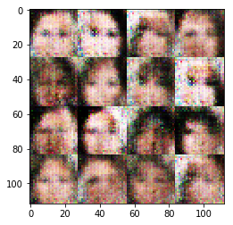

```
Epoch: 1/1... Discriminator Training Loss: 1.2905 Generator Training Loss: 0.7617
Epoch: 1/1... Discriminator Training Loss: 1.2430 Generator Training Loss: 0.7834
Epoch: 1/1... Discriminator Training Loss: 1.3752 Generator Training Loss: 0.6364
Epoch: 1/1... Discriminator Training Loss: 1.0237 Generator Training Loss: 1.1022
Epoch: 1/1... Discriminator Training Loss: 1.1553 Generator Training Loss: 0.8636
Epoch: 1/1... Discriminator Training Loss: 1.1053 Generator Training Loss: 0.8627
Epoch: 1/1... Discriminator Training Loss: 0.8918 Generator Training Loss: 1.0659
Epoch: 1/1... Discriminator Training Loss: 1.0343 Generator Training Loss: 0.8471
Epoch: 1/1... Discriminator Training Loss: 0.8969 Generator Training Loss: 1.1162
Epoch: 1/1... Discriminator Training Loss: 0.9305 Generator Training Loss: 0.9213
```

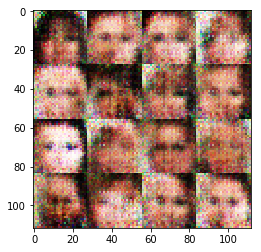

```
Epoch: 1/1... Discriminator Training Loss: 0.8768 Generator Training Loss: 1.0021
Epoch: 1/1... Discriminator Training Loss: 0.7755 Generator Training Loss: 1.1934
Epoch: 1/1... Discriminator Training Loss: 0.8021 Generator Training Loss: 1.0151
Epoch: 1/1... Discriminator Training Loss: 0.8919 Generator Training Loss: 0.9274
Epoch: 1/1... Discriminator Training Loss: 0.6588 Generator Training Loss: 1.5101
Epoch: 1/1... Discriminator Training Loss: 0.6569 Generator Training Loss: 1.3567
Epoch: 1/1... Discriminator Training Loss: 0.5513 Generator Training Loss: 1.5176
Epoch: 1/1... Discriminator Training Loss: 0.6269 Generator Training Loss: 1.4143
Epoch: 1/1... Discriminator Training Loss: 0.6114 Generator Training Loss: 1.1916
Epoch: 1/1... Discriminator Training Loss: 0.4434 Generator Training Loss: 1.8087
```

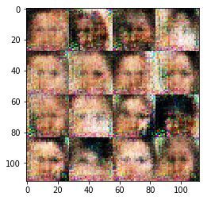

```
Epoch: 1/1... Discriminator Training Loss: 0.5268 Generator Training Loss: 1.4040
Epoch: 1/1... Discriminator Training Loss: 0.3154 Generator Training Loss: 2.2259
Epoch: 1/1... Discriminator Training Loss: 0.5490 Generator Training Loss: 1.1879
Epoch: 1/1... Discriminator Training Loss: 0.4735 Generator Training Loss: 1.4463
Epoch: 1/1... Discriminator Training Loss: 0.3878 Generator Training Loss: 1.8597
Epoch: 1/1... Discriminator Training Loss: 0.4525 Generator Training Loss: 1.6501
Epoch: 1/1... Discriminator Training Loss: 0.3524 Generator Training Loss: 2.0353
Epoch: 1/1... Discriminator Training Loss: 0.3366 Generator Training Loss: 2.0356
Epoch: 1/1... Discriminator Training Loss: 0.4482 Generator Training Loss: 1.5425
Epoch: 1/1... Discriminator Training Loss: 0.4873 Generator Training Loss: 1.4869
```

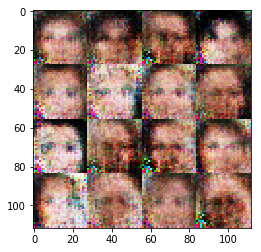

```
Epoch: 1/1... Discriminator Training Loss: 0.3512 Generator Training Loss: 1.7979
Epoch: 1/1... Discriminator Training Loss: 0.3327 Generator Training Loss: 1.9165
Epoch: 1/1... Discriminator Training Loss: 0.4541 Generator Training Loss: 1.6001
Epoch: 1/1... Discriminator Training Loss: 0.3110 Generator Training Loss: 2.7318
Epoch: 1/1... Discriminator Training Loss: 0.4616 Generator Training Loss: 1.5181
Epoch: 1/1... Discriminator Training Loss: 0.3908 Generator Training Loss: 1.8015
Epoch: 1/1... Discriminator Training Loss: 0.2596 Generator Training Loss: 3.2176
Epoch: 1/1... Discriminator Training Loss: 0.3602 Generator Training Loss: 2.7182
Epoch: 1/1... Discriminator Training Loss: 0.4581 Generator Training Loss: 2.4441
Epoch: 1/1... Discriminator Training Loss: 0.2533 Generator Training Loss: 3.9648
```

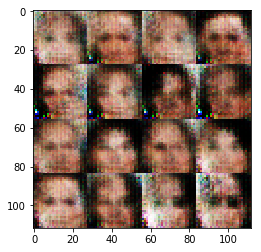

```
Epoch: 1/1... Discriminator Training Loss: 1.2257 Generator Training Loss: 2.5177
Epoch: 1/1... Discriminator Training Loss: 0.9868 Generator Training Loss: 1.7301
Epoch: 1/1... Discriminator Training Loss: 0.6283 Generator Training Loss: 1.2451
Epoch: 1/1... Discriminator Training Loss: 0.6918 Generator Training Loss: 1.7106
Epoch: 1/1... Discriminator Training Loss: 0.9428 Generator Training Loss: 1.5553
Epoch: 1/1... Discriminator Training Loss: 0.6925 Generator Training Loss: 1.3643
Epoch: 1/1... Discriminator Training Loss: 0.7517 Generator Training Loss: 1.3518
Epoch: 1/1... Discriminator Training Loss: 0.8862 Generator Training Loss: 0.8556
Epoch: 1/1... Discriminator Training Loss: 0.5173 Generator Training Loss: 1.7804
Epoch: 1/1... Discriminator Training Loss: 1.1916 Generator Training Loss: 2.1957
```

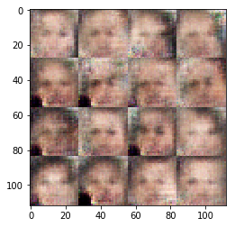

```
Epoch: 1/1... Discriminator Training Loss: 0.9421 Generator Training Loss: 1.1300
Epoch: 1/1... Discriminator Training Loss: 0.9100 Generator Training Loss: 0.9341
Epoch: 1/1... Discriminator Training Loss: 1.0318 Generator Training Loss: 0.7499
Epoch: 1/1... Discriminator Training Loss: 0.7279 Generator Training Loss: 1.1190
Epoch: 1/1... Discriminator Training Loss: 0.5111 Generator Training Loss: 3.3261
Epoch: 1/1... Discriminator Training Loss: 0.6674 Generator Training Loss: 1.2426
Epoch: 1/1... Discriminator Training Loss: 0.6589 Generator Training Loss: 2.0901
Epoch: 1/1... Discriminator Training Loss: 0.5881 Generator Training Loss: 2.0899
Epoch: 1/1... Discriminator Training Loss: 0.6205 Generator Training Loss: 1.8138
Epoch: 1/1... Discriminator Training Loss: 0.5010 Generator Training Loss: 2.5547
```

[20 more figures not shown]

```python
batch_size = 64
z_dim = 100
learning_rate = 0.0002
beta1 = 0.6


"""
DON'T MODIFY ANYTHING IN THIS CELL THAT IS BELOW THIS LINE
"""
epochs = 1

celeba_dataset = helper.Dataset('celeba', glob(os.path.join(data_dir, 'img_align_celeba/*.jpg')))
with tf.Graph().as_default():
    train(epochs, batch_size, z_dim, learning_rate, beta1, celeba_dataset.get_batches,
          celeba_dataset.shape, celeba_dataset.image_mode)
```

### Submitting This Project

When submitting this project, make sure to run all the cells before saving the notebook. Save the notebook file as "dlnd_face_generation.ipynb" and save it as a HTML file under "File" -> "Download as". Include the "helper.py" and "problem_unittests.py" files in your submission.